# Confidence intervals

POLI 210 - Seminar 10

Brad LeVeck

November 4, 2026

## A point estimate leaves a question open

| Mailing | Turnout | Individuals |
| --- | --- | --- |
| Neighbors | 37.8% | 38,201 |
| Civic duty | 31.5% | 38,218 |

The estimated difference is **6.3 percentage points**.

How much would that estimate vary if we repeated the study?

A confidence interval uses the **sampling distribution** to attach an interval to the estimate.

Gerber, Green, and Larimer (2008), rounded summaries used in Blackwell’s slides. We use a simplified independent-samples calculation below.

## The endpoints vary; the parameter is fixed

An interval estimator produces two functions of the sample:

$$[L(X_1,\ldots,X_n),\ U(X_1,\ldots,X_n)].$$

Its **coverage** is the probability that it contains the population parameter:

$$P_\theta(L\leq\theta\leq U).$$

- A 95% procedure aims for coverage of 0.95 across repeated samples.
- $1-\alpha$ is the confidence level; for 95%, $\alpha=0.05$.
- Exact coverage depends on a model; approximate intervals rely on an approximation.

## Start with the sampling distribution

For two independent samples, define

$$\Delta=\mu_Y-\mu_X,\qquad \widehat D=\overline Y-\overline X.$$

Estimate the standard deviation of $\widehat D$ using

$$\widehat{\operatorname{SE}}(\widehat D)
=\sqrt{\frac{S_Y^2}{n_Y}+\frac{S_X^2}{n_X}}.$$

When both samples are large enough for the Normal approximation,

$$\frac{\widehat D-\Delta}{\widehat{\operatorname{SE}}(\widehat D)}
\ \text{is approximately}\ N(0,1).$$

## A familiar probability becomes a useful bound

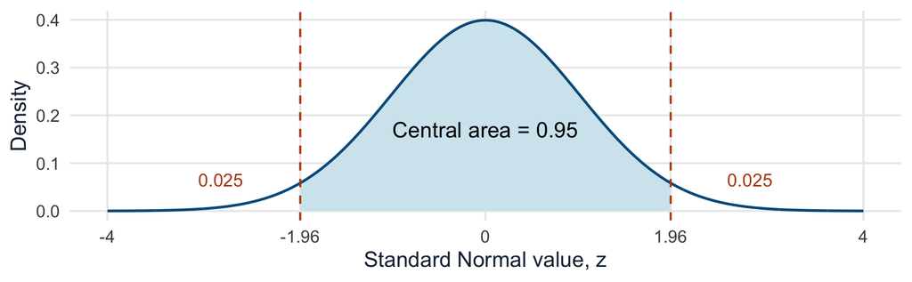

$$P\left(-1.96\leq
\frac{\widehat D-\Delta}{\widehat{\operatorname{SE}}}
\leq1.96\right)\approx0.95.$$

## Rearrange the same event

$$\begin{aligned}
-1.96&\leq\frac{\widehat D-\Delta}{\widehat{\operatorname{SE}}}\leq1.96\\[6pt]
-1.96\widehat{\operatorname{SE}}&\leq\widehat D-\Delta\leq1.96\widehat{\operatorname{SE}}\\[6pt]
\widehat D-1.96\widehat{\operatorname{SE}}&\leq\Delta\leq\widehat D+1.96\widehat{\operatorname{SE}}.
\end{aligned}$$

The resulting approximate 95% confidence interval is

$$\boxed{\widehat D\ \pm\ 1.96\widehat{\operatorname{SE}}.}$$

The endpoints change with the sample. $\Delta$ does not.

## Calculate an interval for the turnout difference

```r
p_neigh <- .378; n_neigh <- 38201
p_civic <- .315; n_civic <- 38218
estimate <- p_neigh - p_civic
# Plug-in Bernoulli variances; rounded published proportions
se_diff <- sqrt(p_neigh * (1 - p_neigh) / n_neigh +
                p_civic * (1 - p_civic) / n_civic)
100 * (estimate + c(-1, 1) * qnorm(.975) * se_diff)
```

```
[1] 5.626713 6.973287
```

Approximately **5.63 to 6.97 percentage points** under this simplified model.

The original experiment assigned households. This individual-level, independent-samples SE illustrates the formula; inference for the actual study must account for its assignment design.

## What does 95% confidence mean?

Across repeated samples, about 95% of the intervals from a well-calibrated 95% procedure contain the fixed parameter.

After observing one interval, it either contains that parameter or it does not; we usually cannot tell which.

- **95% describes the procedure’s repeated coverage.**
- It does not mean 95% of individual outcomes lie inside the interval.
- In this frequentist framework, it does not assign a 95% probability to the fixed parameter being in the realized interval.

## Simulate one sample and one interval

Use $X_i\overset{\mathrm{iid}}{\sim}N(1,10)$: mean 1, **variance 10**.

```r
set.seed(2143)
mu <- 1; sigma <- sqrt(10); n <- 500
x <- rnorm(n, mean = mu, sd = sigma)
estimate <- mean(x)
se <- sd(x) / sqrt(n)
lower <- estimate - qnorm(.975) * se
upper <- estimate + qnorm(.975) * se
lower <= mu & mu <= upper
```

We know $\mu$ because this is a simulation. In an application, $\mu$ is the unknown target.

## Repeat the whole sampling process

```r
B <- 10000
set.seed(2143)
ci <- data.frame(lower = rep(NA_real_, B), upper = rep(NA_real_, B))
for (i in seq_len(B)) {
  x <- rnorm(n, mean = mu, sd = sigma)
  margin <- qnorm(.975) * sd(x) / sqrt(n)
  ci$lower[i] <- mean(x) - margin
  ci$upper[i] <- mean(x) + margin
}
ci$covers <- ci$lower <= mu & mu <= ci$upper
mean(ci$covers)
```

This run: **94.98% coverage** over 10,000 samples.

$n$ is the size of each sample. $B$ is the number of repetitions.

## Many intervals, one population mean

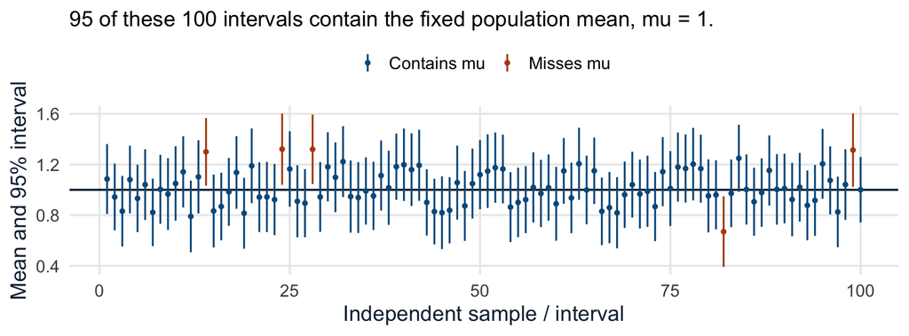

The long-run target is 95%; a batch of 100 need not have exactly 95 successes.

## Choose the confidence level using a quantile

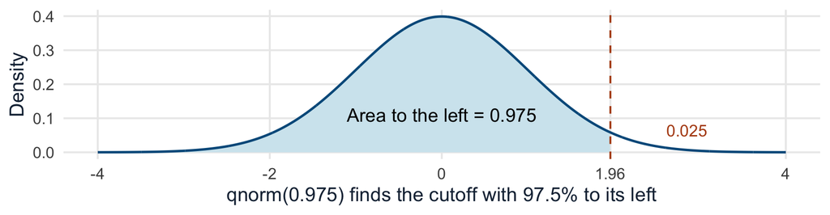

$$\widehat\theta\ \pm\ c\widehat{\operatorname{SE}},\qquad
c=\texttt{qnorm}(1-\alpha/2).$$

For 90% confidence: $\alpha=.10$, so `qnorm(.95)` $\approx1.645$.

This formula requires the standardized estimator to be approximately Normal.

## Greater confidence requires a wider interval

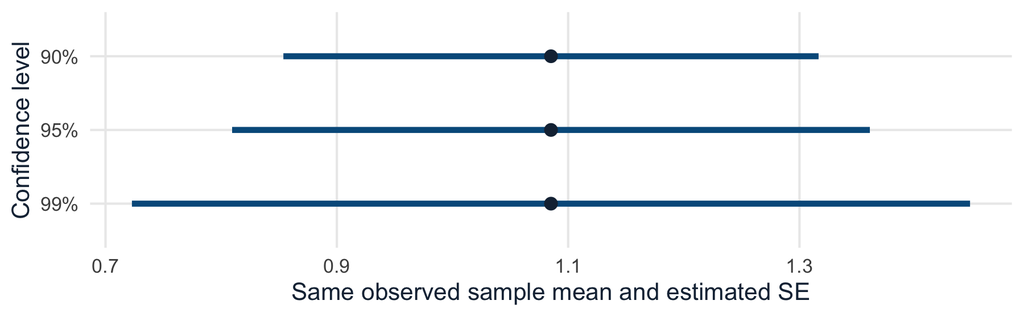

Normal critical values: **1.645**, **1.960**, **2.576** for 90%, 95%, 99%.

The estimate and SE are unchanged here. Only the confidence level changes.

## More information can narrow the interval

For a sample mean with independent observations,

$$\widehat{\operatorname{SE}}(\overline X)=\frac{S}{\sqrt n},\qquad
\text{margin of error}=c\frac{S}{\sqrt n}.$$

- Holding $S$ and $c$ fixed, quadrupling $n$ halves the margin of error.
- Greater variability in observations produces a wider interval.
- More observations do not automatically remove selection bias or measurement bias.

Precision and accuracy are different questions.

## The large-sample argument permits an estimated SE

For iid observations with finite, positive variance,

$$T_n=\frac{\overline X-\mu}{S/\sqrt n}
=\frac{\sigma}{S}\frac{\sqrt n(\overline X-\mu)}{\sigma}
\xrightarrow{d}N(0,1).$$

- The CLT gives a Normal limit for the second factor.
- Consistency of $S$ makes $\sigma/S$ approach 1.
- These conditions allow many population shapes, including skewed distributions.

Estimating the SE preserves our asymptotic justification for the interval.

## Normal observations give an exact t result

If the iid observations are also Normal, $T_n\sim t_{n-1}$ exactly. Then

$$\boxed{\overline X\ \pm\ t_{\alpha/2}\frac{S}{\sqrt n}}$$

has exact $100(1-\alpha)\%$ coverage even in small samples.

PSD labels the positive cutoff by its **upper-tail area**:

$$P(T>t_{\alpha/2})=\alpha/2,\qquad
t_{\alpha/2}=\texttt{qt}(1-\alpha/2,\ n-1).$$

R’s default quantile input is the area **to the left**. Thus `qt(.975, 9)` gives the book’s $t_{0.025}$ for 9 df.

## Calculate the t interval in R

```r
set.seed(210)
x <- rnorm(10, mean = 1, sd = sqrt(10))
n <- length(x)
se <- sd(x) / sqrt(n)
critical <- qt(.975, df = n - 1)
manual_ci <- mean(x) + c(-1, 1) * critical * se
round(manual_ci, 3)
```

```
[1] -0.982  3.693
```

```r
round(as.numeric(t.test(x, conf.level = .95)$conf.int), 3)
```

```
[1] -0.982  3.693
```

Both calculate the same interval for the **population mean**. The sample mean `mean(x)` is already known from these observations.

## The t cutoff also fits the asymptotic argument

At a fixed confidence level, `qt(1 - alpha/2, n - 1)` approaches `qnorm(1 - alpha/2)`.

| n | Reference | Cutoff | Simulated | Exact |
| --- | --- | --- | --- | --- |
| 10 | Normal | 1.960 | 91.70% | 91.84% |
| 10 | t | 2.262 | 94.76% | 95.00% |
| 500 | Normal | 1.960 | 95.02% | 94.94% |
| 500 | t | 1.965 | 95.06% | 95.00% |

Coverage for an iid Normal benchmark, unknown variance, 10,000 samples per setting. Monte Carlo SE is about 0.2–0.3 percentage points.

Under the broader conditions on slide 15, **both cutoffs give asymptotically correct coverage**. Choosing a $t$ cutoff does not itself assume a Normal population.

## Coverage depends on the data-generating process

- **Population shape:** Normality gives an exact one-sample $t$ result. For non-Normal data, coverage is approximate; skewness and heavy tails can slow convergence.
- **Independence:** repeated observations on the same person, household, or time series need an SE that reflects that dependence.
- **Sampling and measurement:** the sample must support inference about the intended population and quantity.

Histograms, boxplots, and Q–Q plots help assess shape and unusual values. The study design tells us about independence.

## A t cutoff does not fix a strongly skewed sample

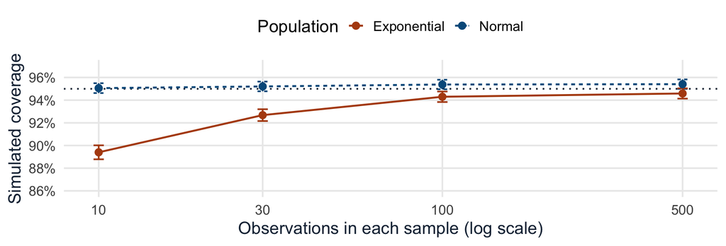

Both populations have mean 1 and variance 1. Each point uses 10,000 samples; whiskers are $\pm2$ Monte Carlo SEs. The dotted line is 95%.

Close $t$ and Normal cutoffs do not guarantee accurate coverage. The actual statistic must also approach its reference distribution.

## Count independent units, not just rows

Suppose we ask **20 voters** to rate the same candidate **5 times**.

There are 100 ratings, but ratings from one voter share that voter’s underlying opinion.

- Treating all 100 rows as independent can make the SE too small.
- An interval can look precise while missing the population mean too often.
- More repetitions per voter do not substitute for more independently sampled voters.

For this balanced design, analyzing the 20 voter-level averages is one way to respect the independent sampling units.

## Connect this to the whiskers in our graphs

An error bar needs a label: **SD, SE, or a confidence interval?**

- SD describes variation among observations.
- SE describes variation of an estimator across samples.
- An approximate 95% Normal CI is estimate $\pm1.96$ SE.

Estimate $\pm1$ SE has approximately 68% coverage when the standardized estimator is Normal. B4’s 68% bootstrap intervals use a simulated sampling distribution instead.

Neither interval is intended to contain 68% or 95% of the individual observations.

## Questions to carry forward

1. What is random in a confidence interval, and what is fixed?
2. How do confidence level, sample size, and variability change its width?
3. Why can a procedure miss its advertised coverage even when the R code runs correctly?

The general structure is

$$\text{estimate}\ \pm\ \text{critical value}\times\text{estimated SE}.$$

The sampling distribution and the design determine whether that structure works.

## Reading and references

- Matthew Blackwell, *Gov 2000: Estimation and Statistical Inference*, Section 3, pp. 32–49. Lecture sequence and coverage demonstration adapted with permission.
- *Probability, Statistics, and Data*, [Chapter 8](https://probstatsdata.com/HTCI.html): §§8.1–8.2 for $t$ intervals; §8.5 for assumptions and simulation checks.
- Gerber, Green, and Larimer (2008), “Social Pressure and Voter Turnout: Evidence from a Large-Scale Field Experiment,” *American Political Science Review*, 102(1), 33–48.

PSD §§8.3–8.4 introduce testing and one-sided procedures. The following two optional slides connect those sections to today’s intervals.

## Optional: a bound in just one direction

Sometimes the target is a **lower confidence bound** on a population mean.

For iid Normal observations, a 95% lower bound is

$$L=\overline X-\texttt{qt}(.95,n-1)\frac{S}{\sqrt n},\qquad [L,\infty).$$

All 5% of the error probability is in one tail. A two-sided 95% interval instead puts 2.5% in each tail.

```r
t.test(x, alternative = "greater", conf.level = .95)$conf.int
```

Choose the direction before seeing the result. An upper bound works analogously.

## Optional: an interval and a test ask related questions

Suppose we consider a proposed population mean $\mu_0$.

$$\mu_0\text{ lies outside }[\overline X-cS/\sqrt n,\overline X+cS/\sqrt n]$$

if and only if

$$\left|\frac{\overline X-\mu_0}{S/\sqrt n}\right|>c.$$

With $c=\texttt{qt}(.975,n-1)$, this is also the rejection rule for the corresponding two-sided $t$ test at level .05.

If the proposed value is inside the interval, that does not establish that it is true. PSD §8.3 develops the testing framework.